# R Probability Distributions

Dr. Falkenberg

November 2019

## Sources

- Probability Distributions in R (Stat 5101, Geyer), https://www.stat.umn.edu/geyer/old/5101/rlook.html
- Basic Probability Distributions in R Greg Graham, https://rstudio-pubs-static.s3.amazonaws.com/100906_8e3a32dd11c14b839468db756cee7400.html

## Overview

Every distribution that R handles has four functions. There is a root name, for example **norm**, the root name for the normal distribution is norm. This root is prefixed by one of the letters

- p for “probability”, the cumulative distribution function
- q for “quantile”, the inverse cumulative distribution function
- d for “density”, the density function
- r for “random”, a random variable having the specified distribution

For a continuous distribution, the most useful functions for doing problems involving probability calculations are the “p” and “q” functions (cumulative distribution function and the inverse cumulative distribution functions, because the the density calculated by the “d” function can only be used to calculate probabilities via integrals and R doesn’t do integrals.

For a discrete distribution (like the binomial), the “d” function calculates the density, which in this case is a probability $f(x) = P(X = x)$ and hence is useful in calculating probabilities.

The p functions have the logical parameter lower.tail. If TRUE probabilites are $P(X \le x)$, otherwise $P(X>x)$. The q functions have the same parameter with the corresponding meaning.

## Discrete Distributions

### Arbitrary discrete distribution from a sample

```r
dat <- sample(0:20, 30, replace = TRUE)
table(dat)
```

```
## dat
##  0  1  2  5  6  7  8 10 13 14 16 17 18 19 20
##  5  2  2  3  1  2  1  1  2  3  3  2  1  1  1
```

```r
freq.tab <- tibble(
  obs = sort(unique(dat)),
  abs = table(dat),
  rel = abs/length(dat),
  cum = cumsum(rel)
)
freq.tab
```

```
## # A tibble: 15 x 4
##      obs abs     rel          cum
##    <int> <table> <table>    <dbl>
##  1     0 5       0.16666667 0.167
##  2     1 2       0.06666667 0.233
##  3     2 2       0.06666667 0.3
##  4     5 3       0.10000000 0.4
##  5     6 1       0.03333333 0.433
##  6     7 2       0.06666667 0.5
##  7     8 1       0.03333333 0.533
##  8    10 1       0.03333333 0.567
##  9    13 2       0.06666667 0.633
## 10    14 3       0.10000000 0.733
## 11    16 3       0.10000000 0.833
## 12    17 2       0.06666667 0.9
## 13    18 1       0.03333333 0.933
## 14    19 1       0.03333333 0.967
## 15    20 1       0.03333333 1
```

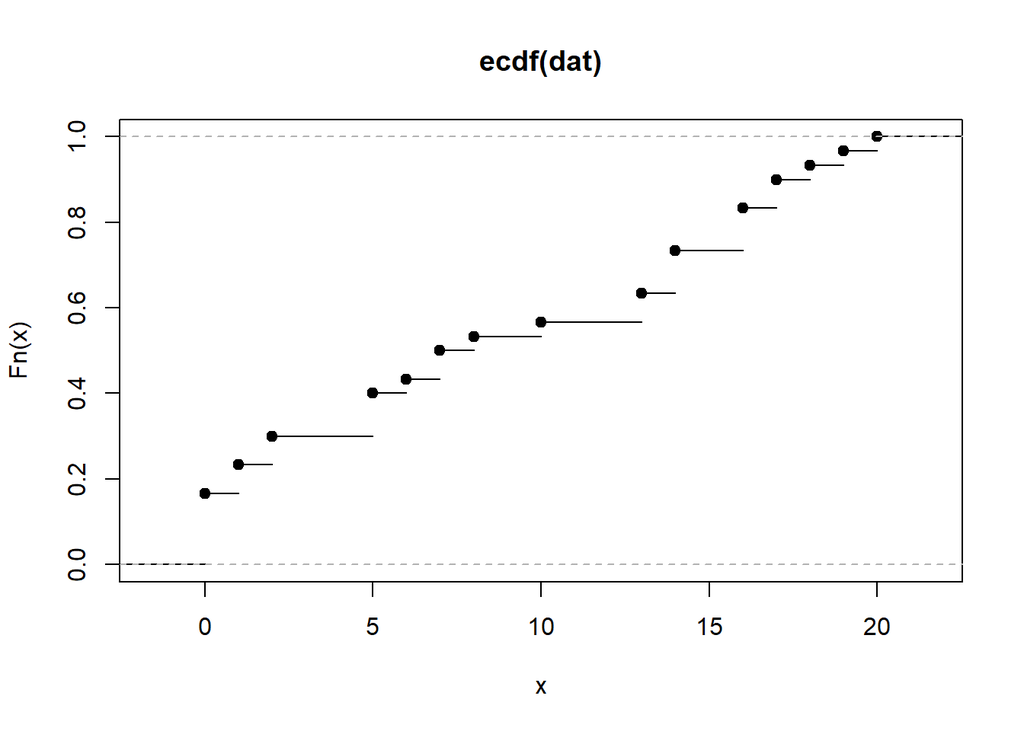

```r
H <- ecdf(dat)
plot(H)
```

```r
pdat <- function(x, lower.tail = TRUE) {
  if (lower.tail == TRUE) return(H(x))
  else return(1-H(x))
}
ddat <- function(x) {
  res <- rep(NA, length(x))
  for (i in 1:length(x)) {
    if (x[i] %in% freq.tab$obs)
      res[i] <- freq.tab$rel[which(freq.tab$obs == x[i])]
    else res[i] <- 0
  }
  return(res)
}
length(0:20)
```

```
## [1] 21
```

```r
x <- 0:20
x[15] %in% freq.tab$obs
```

```
## [1] TRUE
```

```r
freq.tab$abs[15]
```

```
## 20
##  1
```

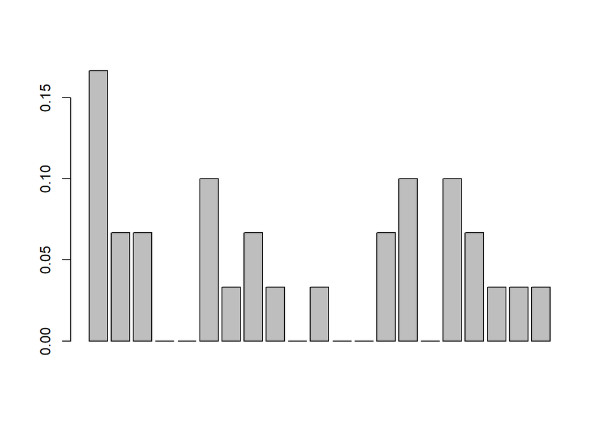

```r
barplot(ddat(0:20))
```

```r
freq.tab
```

```
## # A tibble: 15 x 4
##      obs abs     rel          cum
##    <int> <table> <table>    <dbl>
##  1     0 5       0.16666667 0.167
##  2     1 2       0.06666667 0.233
##  3     2 2       0.06666667 0.3
##  4     5 3       0.10000000 0.4
##  5     6 1       0.03333333 0.433
##  6     7 2       0.06666667 0.5
##  7     8 1       0.03333333 0.533
##  8    10 1       0.03333333 0.567
##  9    13 2       0.06666667 0.633
## 10    14 3       0.10000000 0.733
## 11    16 3       0.10000000 0.833
## 12    17 2       0.06666667 0.9
## 13    18 1       0.03333333 0.933
## 14    19 1       0.03333333 0.967
## 15    20 1       0.03333333 1
```

### Uniform Distributions

The corresponding functions for the discrete uniform distributions are not part of the base package. They are implemented in the package “extrDist”

Example: rolling a fair die

```r
# load the library extraDistr
library(extraDistr)
```

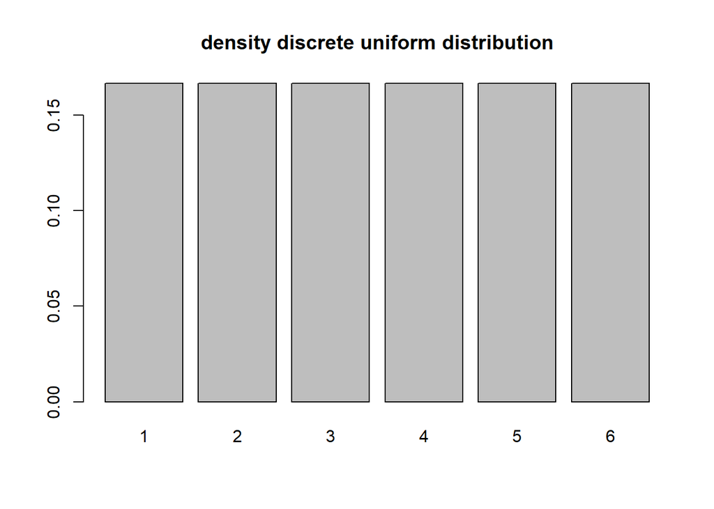

```r
# example rolling a fair die
a <- 1
b <- 6

barplot(ddunif(a:b,a,b),
        names.arg = a:b,
        main = "density discrete uniform distribution")
```

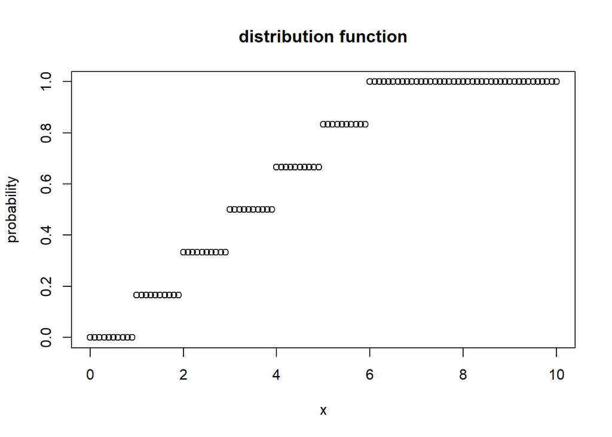

```r
plot(x = seq(0,10,by=0.1), y = pdunif(seq(0,10,by=0.1),a,b),
     xlab = "x", ylab = "probability",
     main = "distribution function")
```

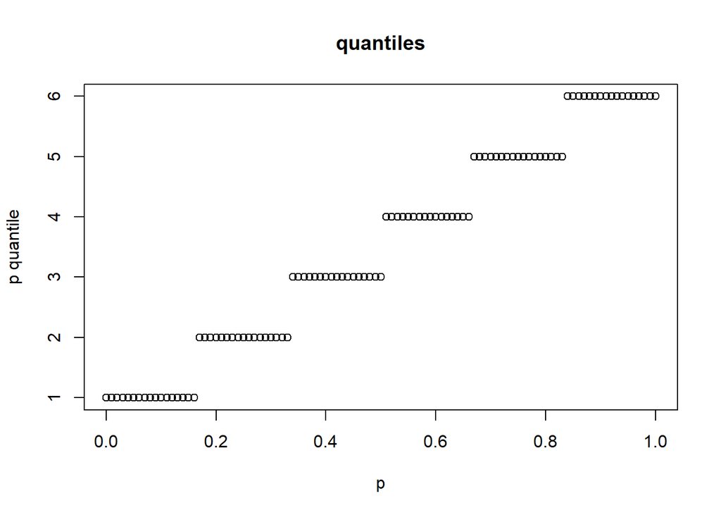

```r
plot(x = seq(0,1,by=0.01), y = qdunif(seq(0,1,by=0.01),a,b),
     xlab = "p", ylab = "p quantile",
     main = "quantiles")
```

```r
rdunif(100,a,b) %>% table()
```

```
## .
##  1  2  3  4  5  6
## 16 17 20 17 14 16
```

Implementation of own functions

```r
# ddunifdisc(x, min, max)
# pdunifdisc(q, min, max, lower.tail = TRUE)
# qdunidisc(p, min, max, lower.tail = TRUE)
# rdunifdisc(n, min, max)
# Arguments:
# x, q : numerical value
# min, max : lower and upper limits of the distribution. Must be an integer.
# p : probability
# n : number of observations

dunifdisc <-  function(x, min, max) {
  result <- rep(NA,length(x))
  for (i in 1:length(x)) {
    if (x[i]>=min & x[i]<=max & round(x[i])==x[i])
      result[i] <- 1/(max-min+1)
    else result[i] <- 0
  }
  return(result)
}
punifdisc <- function(q, min, max) {
  result <- rep(NA,length(q))
  for (i in 1:length(q)) {
    if (q[i] < min) {
      result[i] <- 0
    } else {
      if (q[i] >= max) {
        result[i] <- 1
      }  else {
        result[i] <- (floor(q[i])-min+1)/(max-min+1)
      }
    }
  }
  return(result)
}
qunifdisc <- function(p, min, max) return(floor(p*(max-min+1)))
runifdisc <- function(n, min, max) return(sample(min:max, n, replace=T))

#a <- 1
#b <- 6
#barplot(dunifdisc(a:b,a,b),
#        names.arg = a:b,
#        main = "density discrete uniform distribution")
#plot(x = seq(0,10,by=0.1),
#     y = punifdisc(seq(0,10,by=0.1),a,b),
#     xlab = "x", ylab = "probability",
#     main = "distribution function")
#plot(x = seq(0,1,by=0.01),
#     y = qunifdisc(seq(0,1,by=0.01),a,b),
#     xlab = "p", ylab = "p quantile",
#     main = "quantiles")
#runifdisc(100,a,b) %>% table()
```

### Binomial Distributions

Example: no of sixes in rolling a fair die 10 times

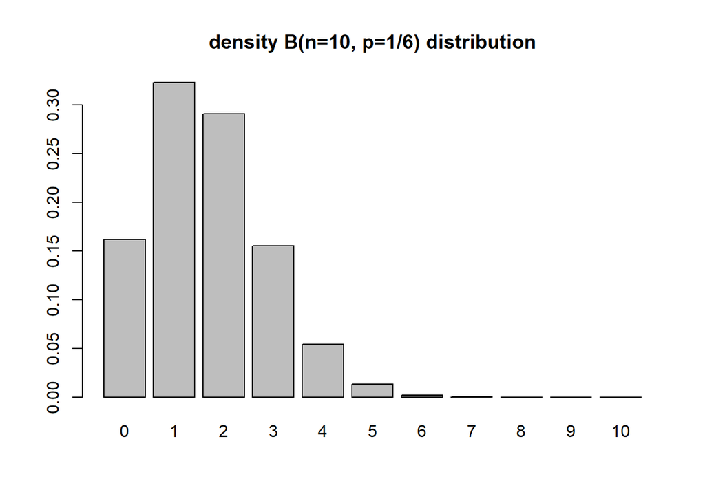

```r
p <- 1/6
n <- 10

barplot(dbinom(0:10,size = n, prob = p),
        names.arg = 0:10,
        main = "density B(n=10, p=1/6) distribution")
```

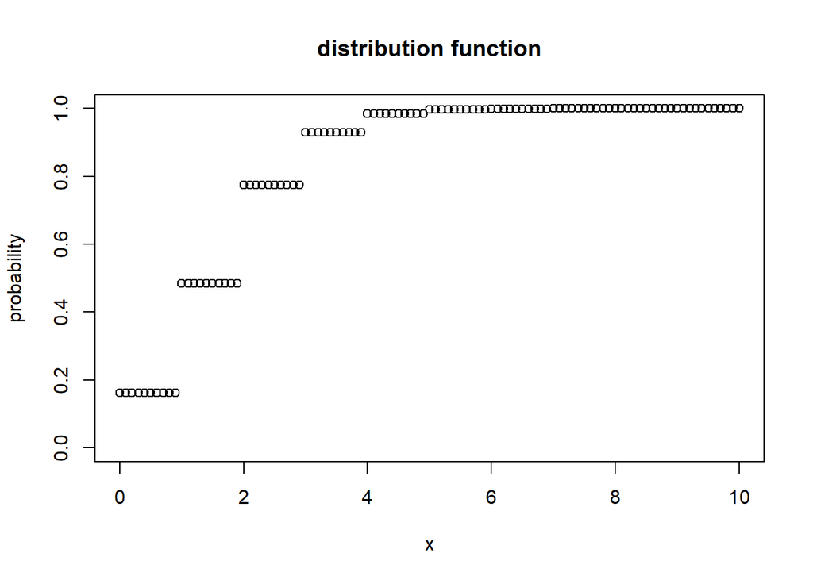

```r
plot(x = seq(0,10,by=0.1),
     y = pbinom(seq(0,10,by=0.1), size = n, prob = p),
     ylim = c(0,1),
     xlab = "x", ylab = "probability",
     main = "distribution function")
```

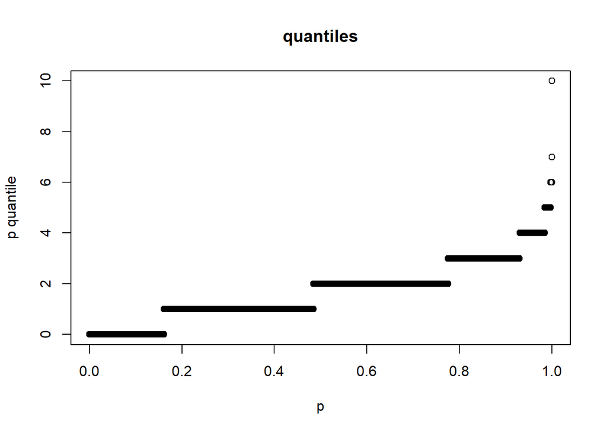

```r
plot(x = seq(0,1,by=0.0001),
     y = qbinom(seq(0,1,by=0.0001), size = n, prob = p),
     xlab = "p", ylab = "p quantile",
     main = "quantiles")
```

```r
rbinom(100,size = n, prob = p) %>% table()
```

```
## .
##  0  1  2  3  4
## 20 23 31 20  6
```

### Hypergeometric Distributions

Example: no of red balls drawn withaout replacement out of an urn with 20 balls, 15 red balls an 10 drawns

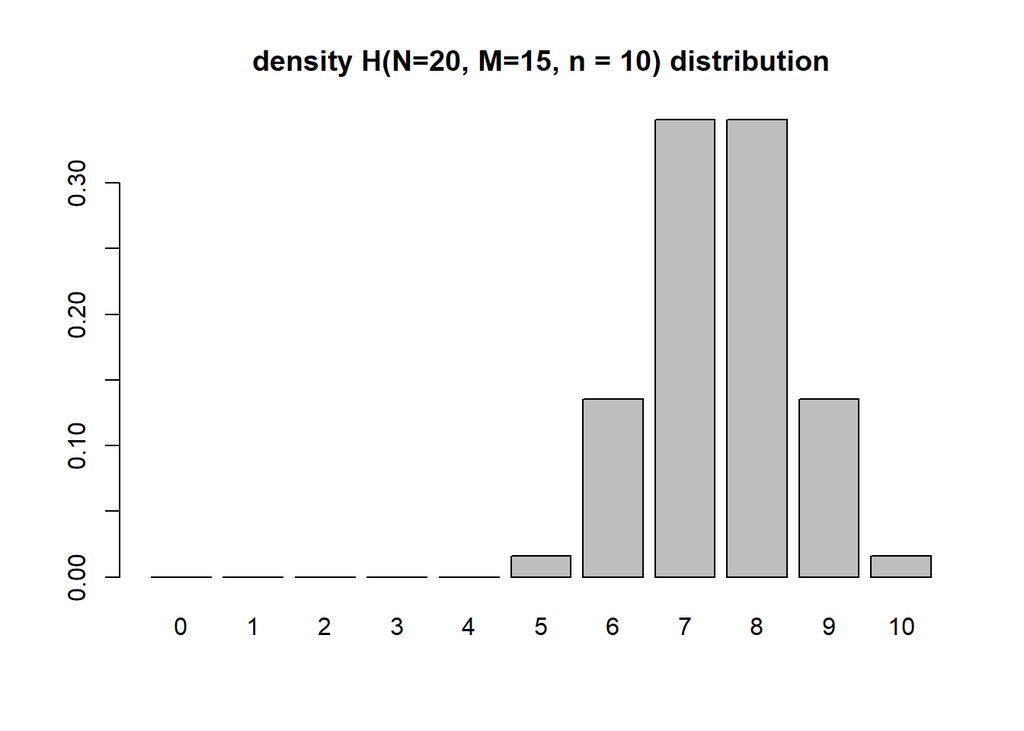

```r
M <- 15 # number of red balls
N <- 20 # total number of balls
n <- 10 # number of balls drawn
barplot(dhyper(0:10, m = M, n = N-M, k = n),
        names.arg = 0:10,
        main = "density H(N=20, M=15, n = 10) distribution")
```

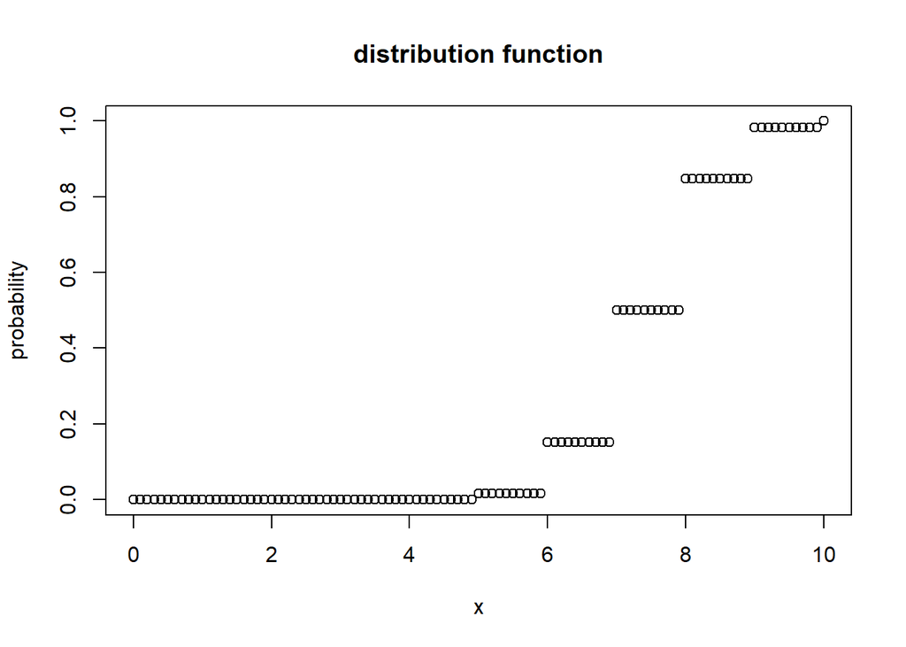

```r
plot(x = seq(0,10,by=0.1),
     y = phyper(seq(0,10,by=0.1), m = M, n = N-M, k = n),
     ylim = c(0,1),
     xlab = "x", ylab = "probability",
     main = "distribution function")
```

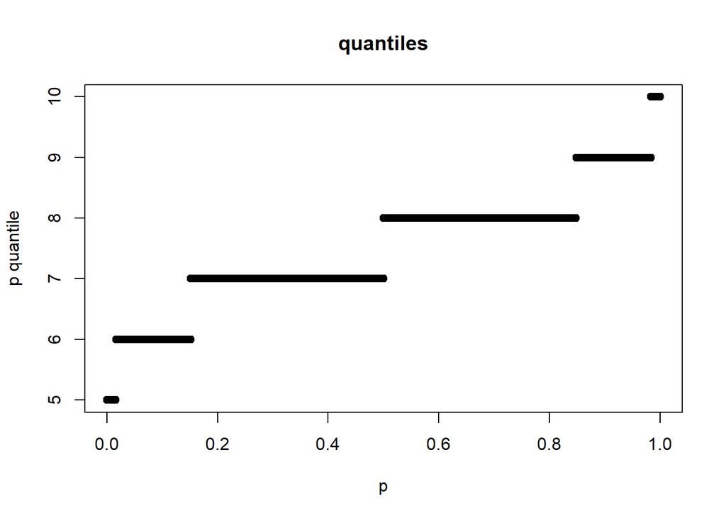

```r
plot(x = seq(0,1,by=0.0001),
     y = qhyper(seq(0,1,by=0.0001), m = M, n = N-M, k = n),
     xlab = "p", ylab = "p quantile",
     main = "quantiles")
```

```r
rhyper(100, m = M, n = N-M, k = n) %>% table()
```

```
## .
##  6  7  8  9 10
## 14 32 39 13  2
```

### Geometric Distributions

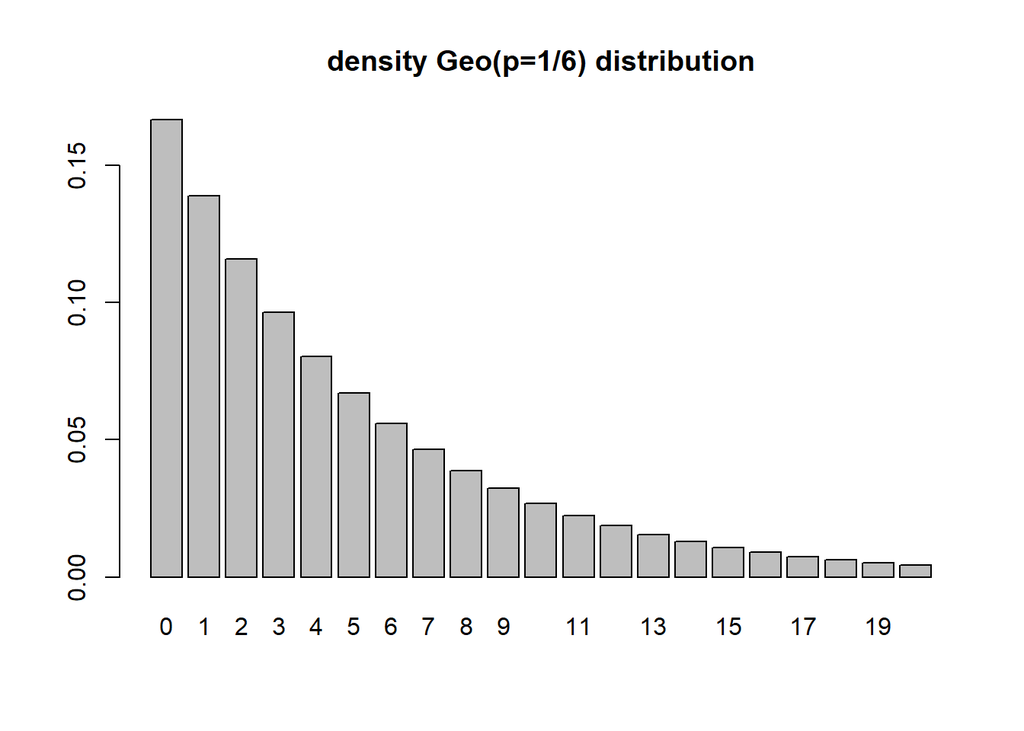

```r
p <- 1/6
barplot(dgeom(0:20, prob = p),
        names.arg = 0:20,
        main = "density Geo(p=1/6) distribution")
```

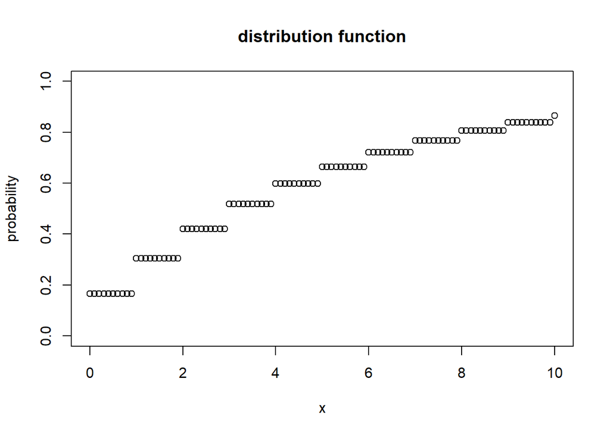

```r
plot(x = seq(0,10,by=0.1),
     y = pgeom(seq(0,10,by=0.1), prob = p),
     ylim = c(0,1),
     xlab = "x", ylab = "probability",
     main = "distribution function")
```

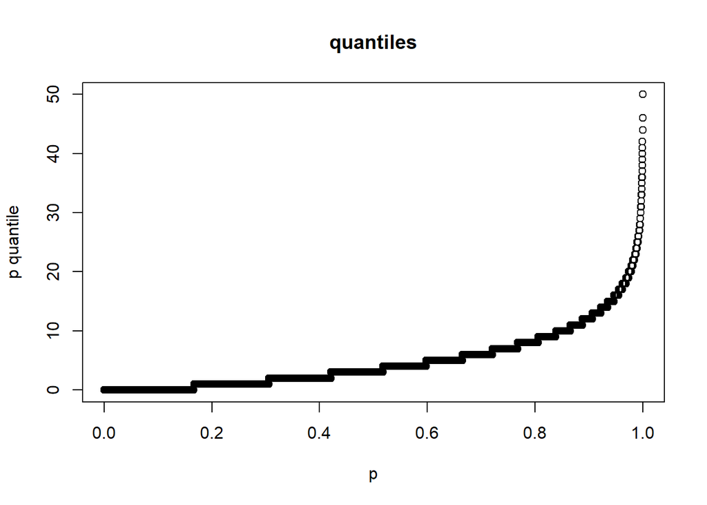

```r
plot(x = seq(0,1,by=0.0001),
     y = qgeom(seq(0,1,by=0.0001), prob = p),
     xlab = "p", ylab = "p quantile",
     main = "quantiles")
```

```r
rgeom(100, prob = p) %>% table()
```

```
## .
##  0  1  2  3  4  5  6  7  8  9 10 11 12 13 15 16 17 19 29
## 20 16 13 12  4  6  6  3  4  6  1  2  1  1  1  1  1  1  1
```

## Continous Distributions

### Uniform Distributions

Example: waiting times to a bus coming exactly every 10 minutes, if you come randomly to the bus stop

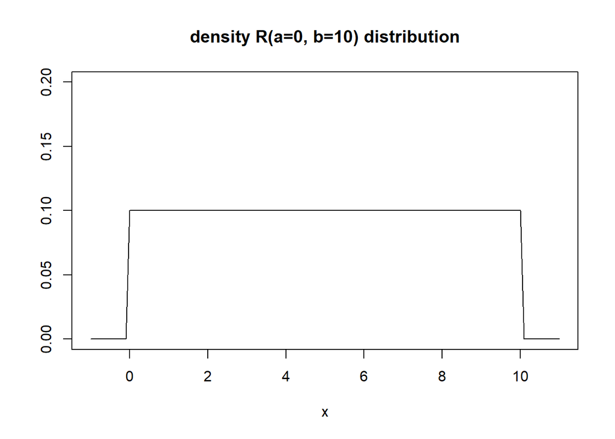

```r
Min <- 0
Max <- 10
plot(x=seq(-1,11,by=0.1),
     y=dunif(seq(-1,11,by=0.1),min = Min, max = Max),
     ylim = c(0,0.2),
     ylab = "", xlab = "x",
     type = "l",
     main = "density R(a=0, b=10) distribution")
```

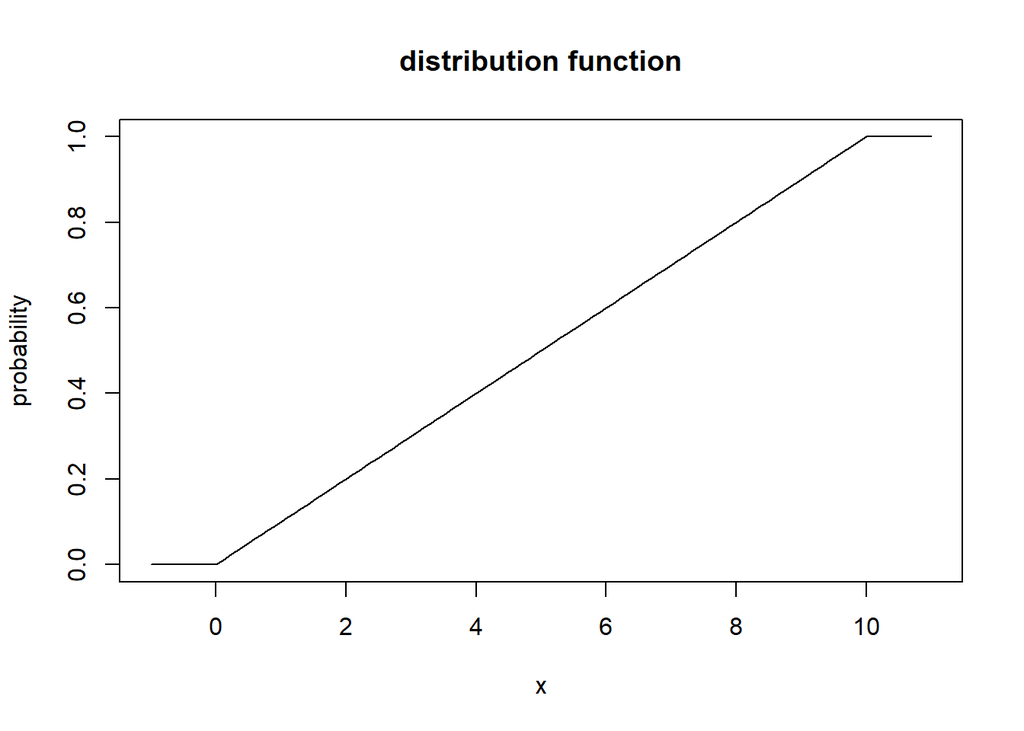

```r
plot(x = seq(-1,11,by=0.1),
     y = punif(seq(-1,11,by=0.1), min = Min, max = Max),
     type = "l",
     xlab = "x", ylab = "probability",
     main = "distribution function")
```

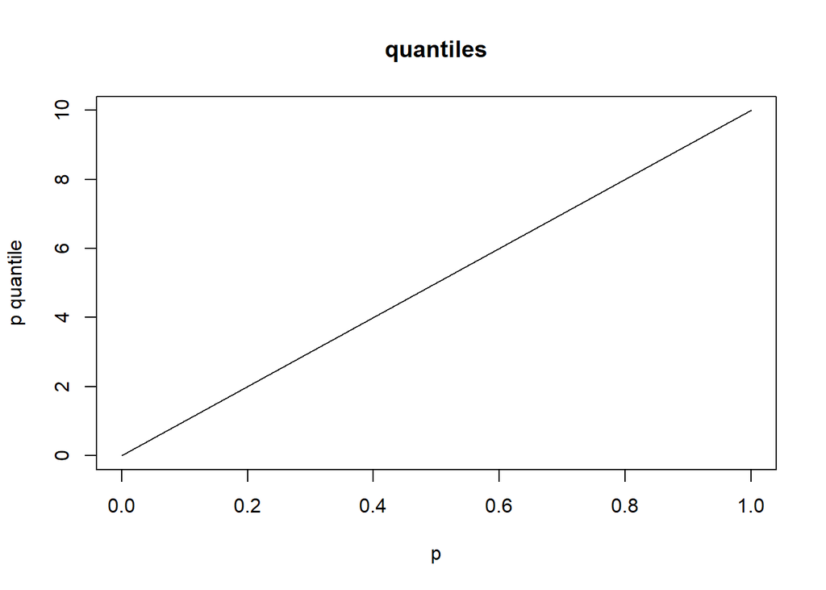

```r
plot(x = seq(0,1,by=0.0001),
     y = qunif(seq(0,1,by=0.0001), min = Min, max = Max),
     xlab = "p", ylab = "p quantile",
     type = "l",
     main = "quantiles")
```

```r
runif(100, min = Min, max = Max) %>%
  cut(breaks = 0:10) %>%
  table()
```

```
## .
##  (0,1]  (1,2]  (2,3]  (3,4]  (4,5]  (5,6]  (6,7]  (7,8]  (8,9] (9,10]
##     11     10     11      8     10     13      8      6     16      7
```

### Normal distributions

Example: mu = 5, sigma = 2

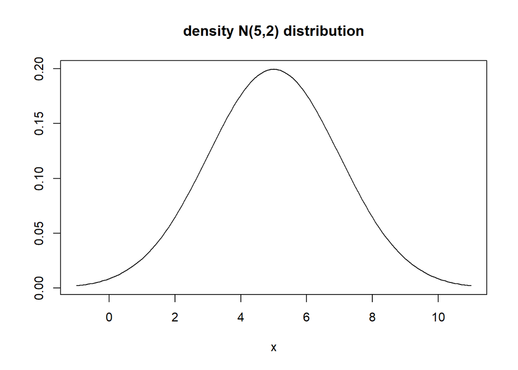

```r
mu <- 5
s <- 2
plot(x=seq(-1,11,by=0.1),
     y=dnorm(seq(-1,11,by=0.1), mean = mu, sd = s),
     ylab = "", xlab = "x",
     type = "l",
     main = "density N(5,2) distribution")
```

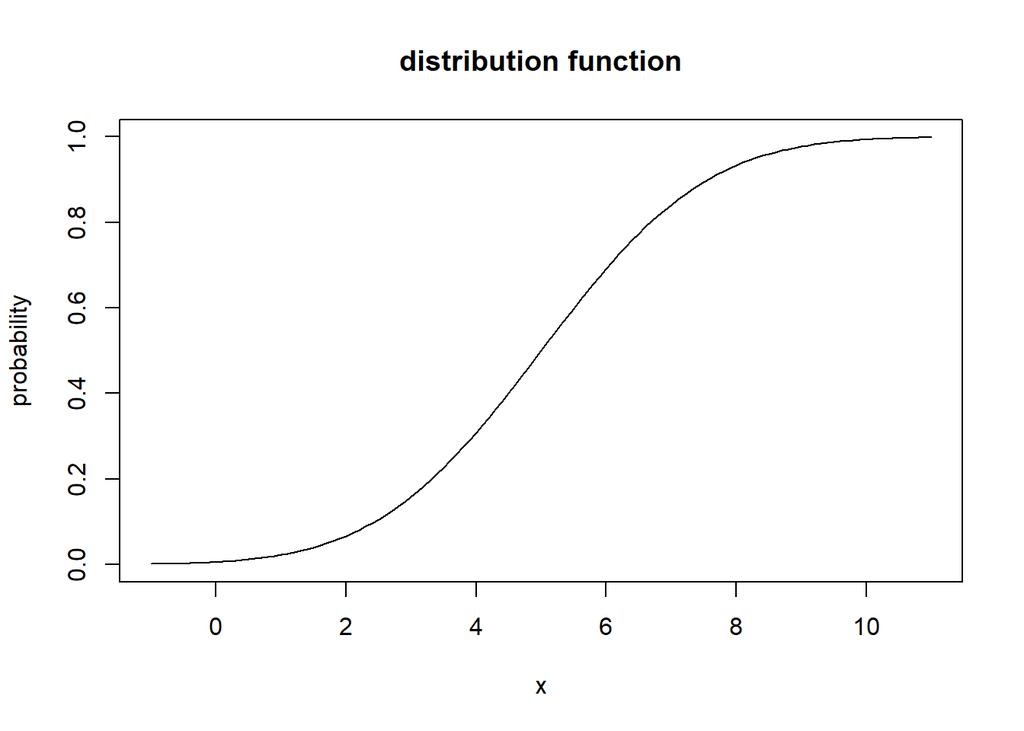

```r
plot(x = seq(-1,11,by=0.1),
     y = pnorm(seq(-1,11,by=0.1), mean = mu, sd = s),
     ylim = c(0,1),
     type = "l",
     xlab = "x", ylab = "probability",
     main = "distribution function")
```

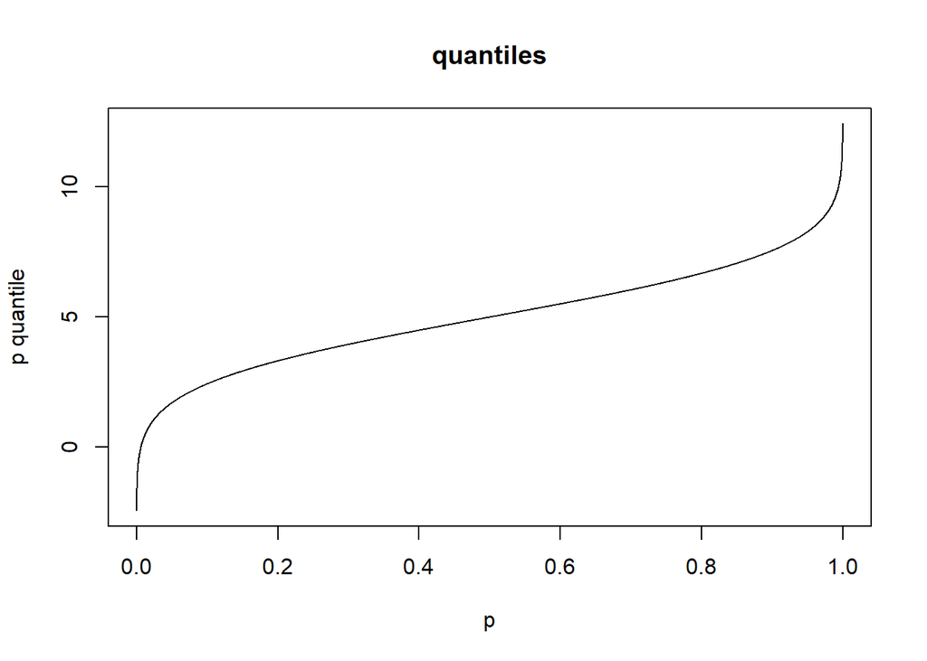

```r
plot(x = seq(0,1,by=0.0001),
     y = qnorm(seq(0,1,by=0.0001), mean = mu, sd = s),
     xlab = "p", ylab = "p quantile",
     type = "l",
     main = "quantiles")
```

```r
rnorm(100, mean = mu, sd = s) %>%
  cut(breaks = 0:10) %>%
  table()
```

```
## .
##  (0,1]  (1,2]  (2,3]  (3,4]  (4,5]  (5,6]  (6,7]  (7,8]  (8,9] (9,10]
##      2      2     14     14     22     18     13      8      6      1
```

### Exponential Distributions

Example: rate = 2

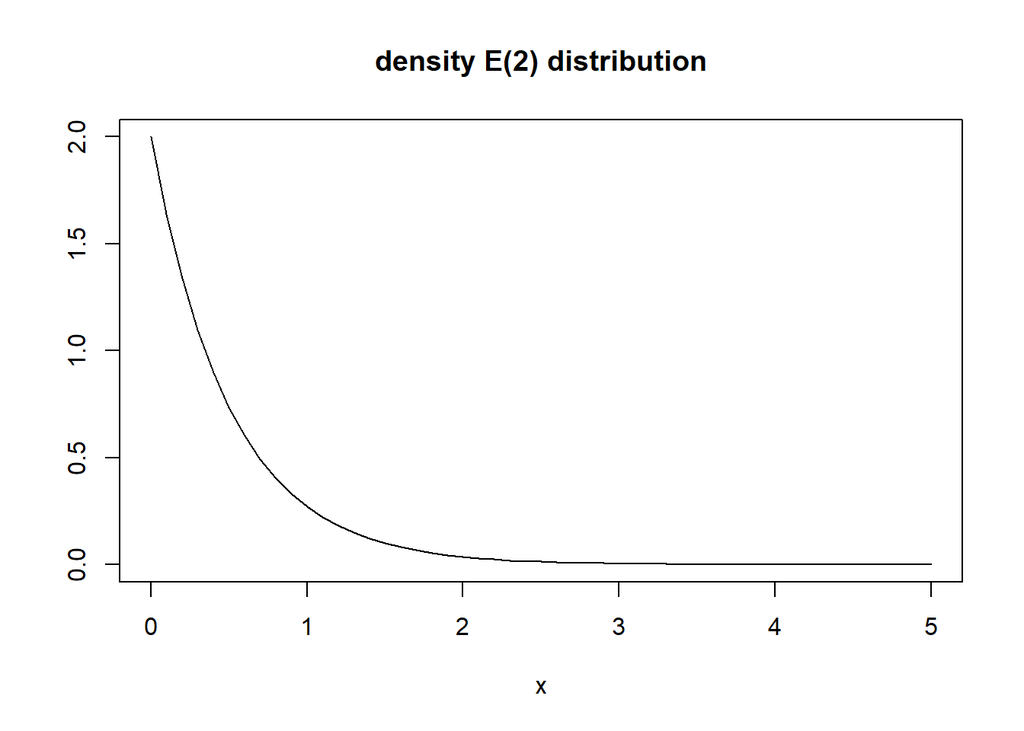

```r
r <- 2
plot(x=seq(0,5,by=0.1),
     y=dexp(seq(0,5,by=0.1), rate = r),
     type = "l",
     ylim = c(0,2),
     ylab = "", xlab = "x",
     main = "density E(2) distribution")
```

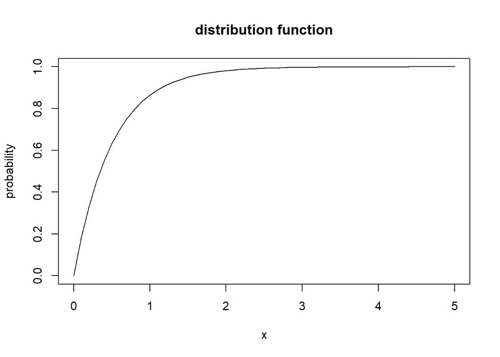

```r
plot(x = seq(0,5,by=0.1),
     y = pexp(seq(0,5,by=0.1), rate = r),
     ylim = c(0,1),
     type = "l",
     xlab = "x", ylab = "probability",
     main = "distribution function")
```

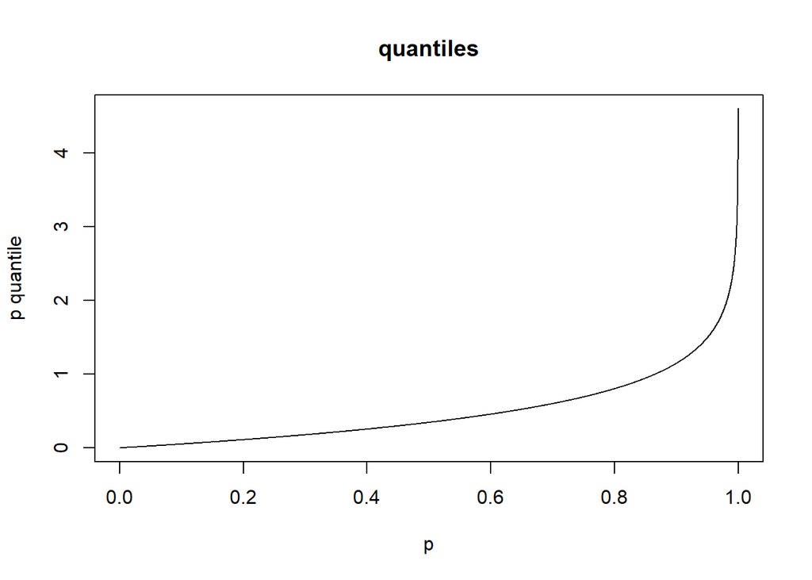

```r
plot(x = seq(0,1,by=0.0001),
     y = qexp(seq(0,1,by=0.0001), rate = r),
     type = "l",
     xlab = "p", ylab = "p quantile",
     main = "quantiles")
```

```r
rexp(100, rate = r) %>% cut(breaks = seq(0,2.5,by=0.1)) %>% table()
```

```
## .
##   (0,0.1] (0.1,0.2] (0.2,0.3] (0.3,0.4] (0.4,0.5] (0.5,0.6] (0.6,0.7] (0.7,0.8]
##        16        13        19        10        10         6         1         5
## (0.8,0.9]   (0.9,1]   (1,1.1] (1.1,1.2] (1.2,1.3] (1.3,1.4] (1.4,1.5] (1.5,1.6]
##         4         3         1         1         3         1         3         1
## (1.6,1.7] (1.7,1.8] (1.8,1.9]   (1.9,2]   (2,2.1] (2.1,2.2] (2.2,2.3] (2.3,2.4]
##         0         0         0         1         0         0         0         0
## (2.4,2.5]
##         0
```

## Student t Distributions

Example: degrees of freedom = 2

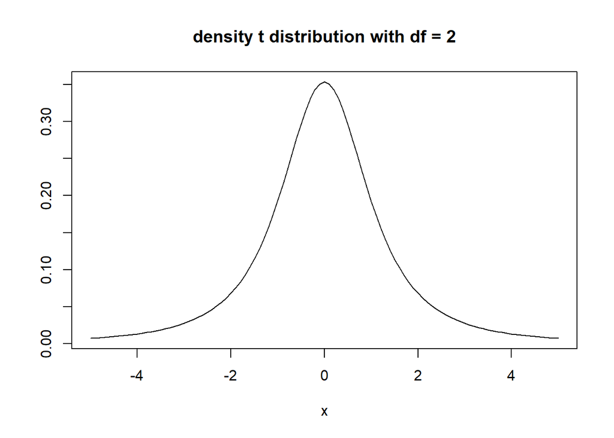

```r
d <- 2
plot(x=seq(-5,5,by=0.1),
     y=dt(seq(-5,5,by=0.1), df = d),
     type = "l",
     ylab = "", xlab = "x",
     main = "density t distribution with df = 2")
```

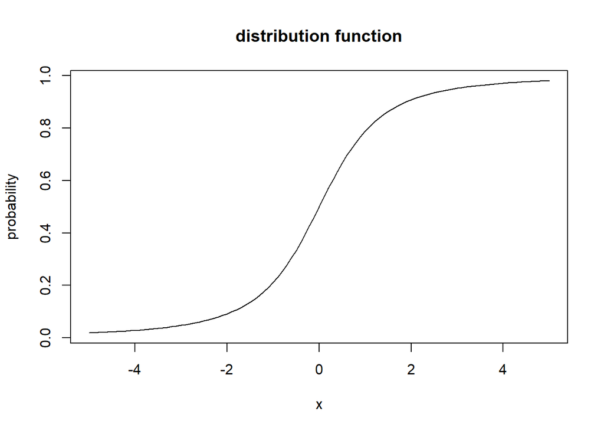

```r
plot(x = seq(-5,5,by=0.1),
     y = pt(seq(-5,5,by=0.1), df = d),
     type = "l",
     xlab = "x", ylab = "probability",
     main = "distribution function")
```

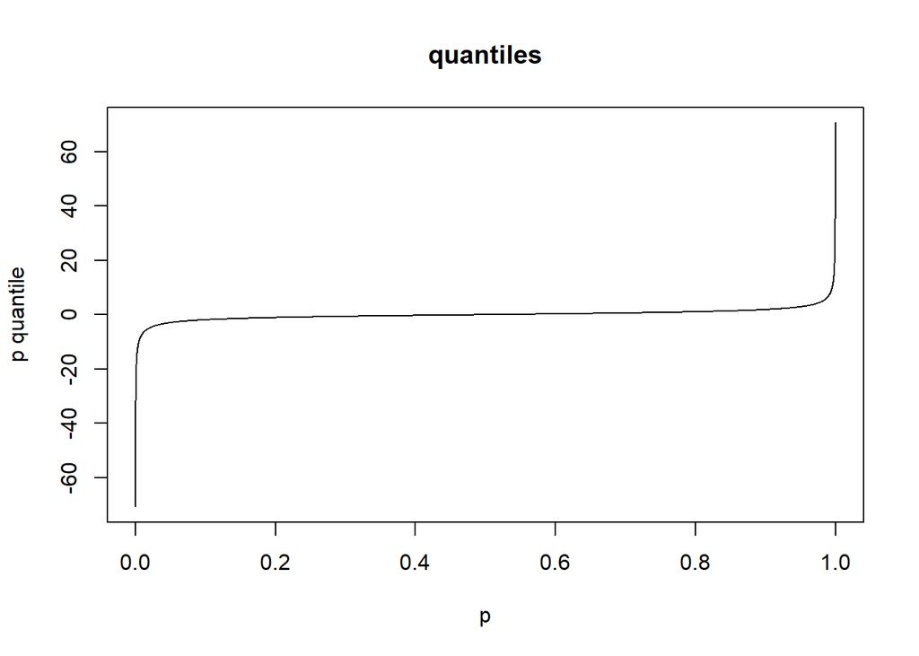

```r
plot(x = seq(0,1,by=0.0001),
     y = qt(seq(0,1,by=0.0001), df = d),
     type = "l",
     xlab = "p", ylab = "p quantile",
     main = "quantiles")
```

```r
rt(100, df = d) %>% cut(breaks = seq(-5,5,by=0.5)) %>% table()
```

```
## .
## (-5,-4.5] (-4.5,-4] (-4,-3.5] (-3.5,-3] (-3,-2.5] (-2.5,-2] (-2,-1.5] (-1.5,-1]
##         0         0         1         0         1         2         4        10
## (-1,-0.5]  (-0.5,0]   (0,0.5]   (0.5,1]   (1,1.5]   (1.5,2]   (2,2.5]   (2.5,3]
##        14        18        14        15         7         3         2         2
##   (3,3.5]   (3.5,4]   (4,4.5]   (4.5,5]
##         1         1         1         0
```

## Chisquare Distributions

Example: degrees of freedom = 3

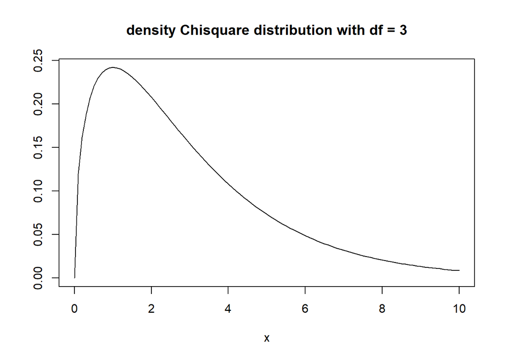

```r
d <- 3
plot(x=seq(0,10,by=0.1),
     y=dchisq(seq(0,10,by=0.1), df = d),
     type = "l",
     ylab = "", xlab = "x",
     main = "density Chisquare distribution with df = 3")
```

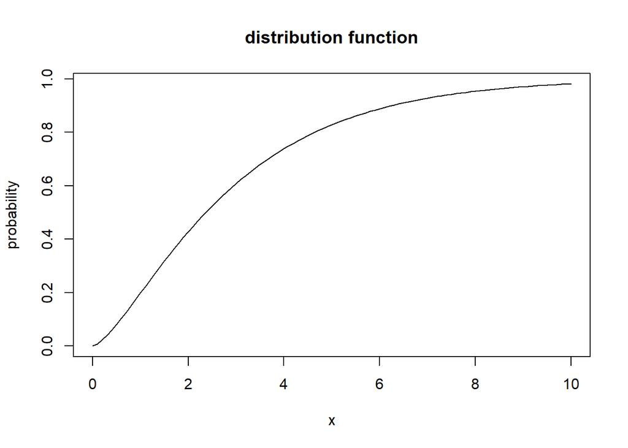

```r
plot(x = seq(0,10,by=0.1),
     y = pchisq(seq(0,10,by=0.1), df = d),
     type = "l",
     xlab = "x", ylab = "probability",
     main = "distribution function")
```

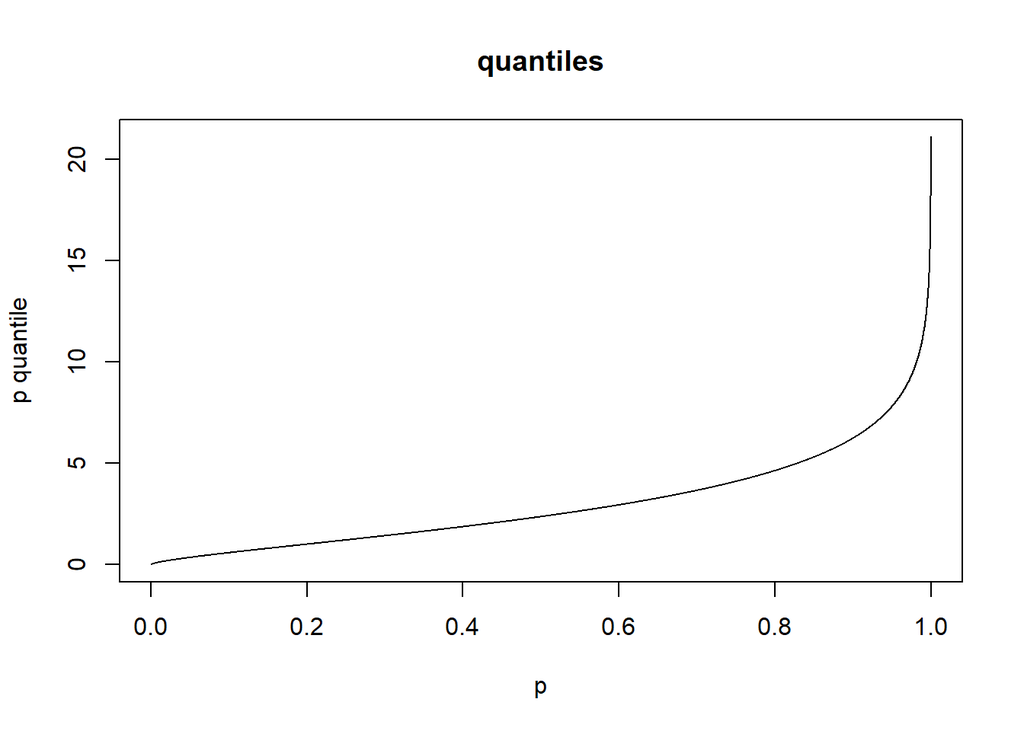

```r
plot(x = seq(0,1,by=0.0001),
     y = qchisq(seq(0,1,by=0.0001), df = d),
     type = "l",
     xlab = "p", ylab = "p quantile",
     main = "quantiles")
```

```r
rchisq(100, df = d) %>% cut(breaks = seq(0,10,by=0.5)) %>% table()
```

```
## .
##  (0,0.5]  (0.5,1]  (1,1.5]  (1.5,2]  (2,2.5]  (2.5,3]  (3,3.5]  (3.5,4]
##       10       11       14        4       11       14        9        1
##  (4,4.5]  (4.5,5]  (5,5.5]  (5.5,6]  (6,6.5]  (6.5,7]  (7,7.5]  (7.5,8]
##        5        4        3        2        2        2        0        2
##  (8,8.5]  (8.5,9]  (9,9.5] (9.5,10]
##        1        1        2        1
```

## F Distributions

Example: degrees of freedom = (10,2)

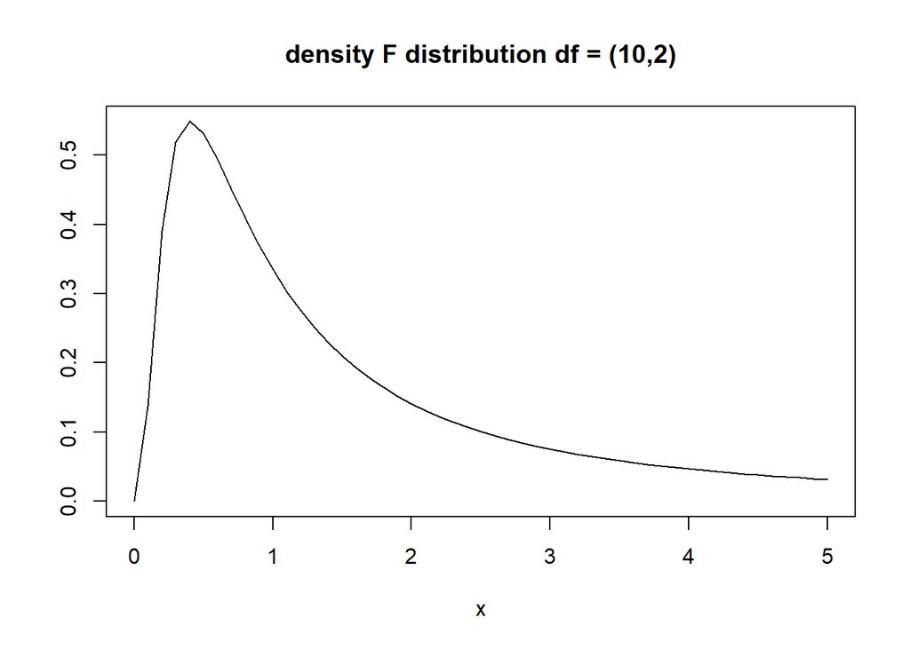

```r
d1 <- 10
d2 <- 2
plot(x=seq(0,5,by=0.1),
     y=df(seq(0,5,by=0.1), df1 = d1, df2 = d2),
     type = "l",
     ylab = "", xlab = "x",
     main = "density F distribution df = (10,2)")
```

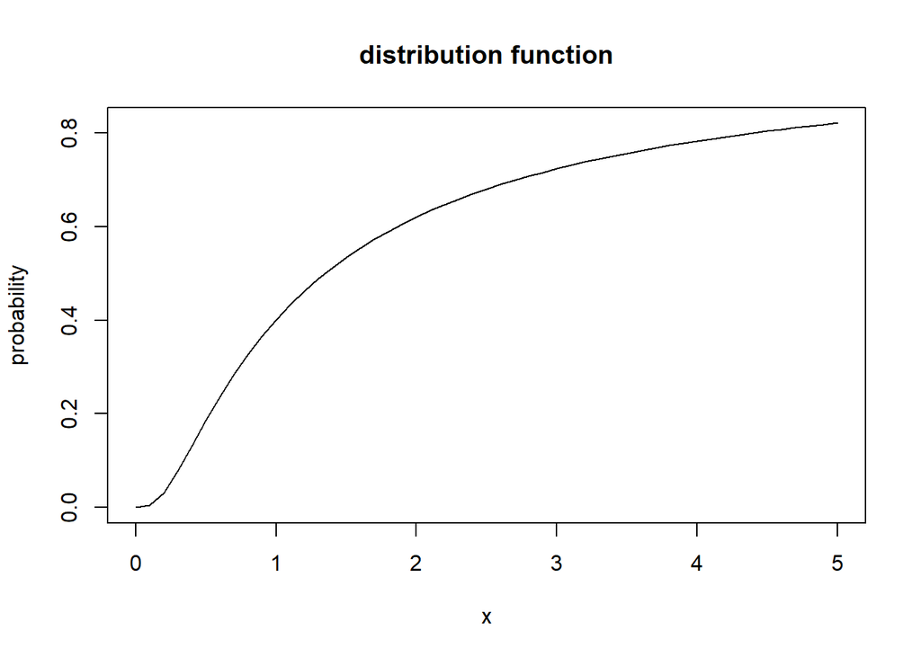

```r
plot(x = seq(0,5,by=0.1),
     y = pf(seq(0,5,by=0.1), df1 = d1, df2 = d2),
     type = "l",
     xlab = "x", ylab = "probability",
     main = "distribution function")
```

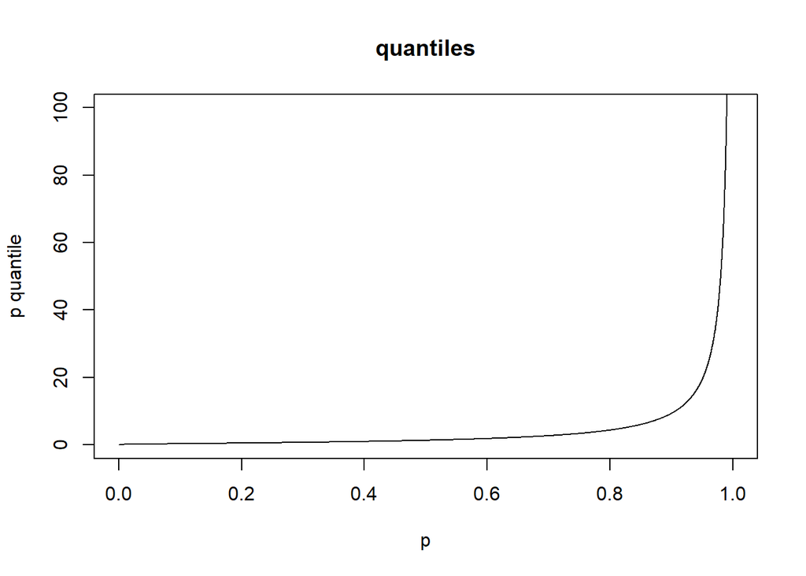

```r
plot(x = seq(0,1,by=0.0001),
     y = qf(seq(0,1,by=0.0001), df1 = d1, df2 = d2),
     type = "l",
     ylim = c(0,100),
     xlab = "p", ylab = "p quantile",
     main = "quantiles")
```

```r
rf(100, df1 = d1, df2 = d2) %>% cut(breaks = seq(0,5,by=0.25)) %>% table()
```

```
## .
##   (0,0.25] (0.25,0.5] (0.5,0.75]   (0.75,1]   (1,1.25] (1.25,1.5] (1.5,1.75]
##          6         13         13         13         11          3          2
##   (1.75,2]   (2,2.25] (2.25,2.5] (2.5,2.75]   (2.75,3]   (3,3.25] (3.25,3.5]
##          4          4          0          1          1          5          0
## (3.5,3.75]   (3.75,4]   (4,4.25] (4.25,4.5] (4.5,4.75]   (4.75,5]
##          0          2          3          1          1          0
```